# RED WINE QUALITY EXPLORATION by FELIPE BARROS

This dataset is one of the datasets created on the paper “Modeling wine preferences by data mining from physicochemical properties” [Cortez et al., 2009]. The inputs include objective tests, such as PH values, and the output is based on sensory data, gathered from at least 3 wine expert evaluations. The output value ranges from 0 (very bad) to 10 (very excellent). The wines are variants of the Portuguese “Vinho Verde” wine. This particular dataset contains information regarding the red wines.

There are 1599 different wines, 11 features and 1 output value (quality). Information about the features and the output value is the following (provided by the original authors):

Input variables (based on physicochemical tests):

- 1 - fixed acidity (tartaric acid - g / dm^3)
- 2 - volatile acidity (acetic acid - g / dm^3)
- 3 - citric acid (g / dm^3)
- 4 - residual sugar (g / dm^3)
- 5 - chlorides (sodium chloride - g / dm^3
- 6 - free sulfur dioxide (mg / dm^3)
- 7 - total sulfur dioxide (mg / dm^3)
- 8 - density (g / cm^3)
- 9 - pH
- 10 - sulphates (potassium sulphate - g / dm3)
- 11 - alcohol (% by volume)

Output variable (based on sensory data):

- 12 - quality (score between 0 and 10)

Description of the features and output value is the following (also provided by the original authors):

- 1 - fixed acidity: most acids involved with wine or fixed or nonvolatile (do not evaporate readily)
- 2 - volatile acidity: the amount of acetic acid in wine, which at too high of levels can lead to an unpleasant, vinegar taste
- 3 - citric acid: found in small quantities, citric acid can add ‘freshness’ and flavor to wines
- 4 - residual sugar: the amount of sugar remaining after fermentation stops, it’s rare to find wines with less than 1 gram/liter and wines with greater than 45 grams/liter are considered sweet
- 5 - chlorides: the amount of salt in the wine
- 6 - free sulfur dioxide: the free form of SO2 exists in equilibrium between molecular SO2 (as a dissolved gas) and bisulfite ion; it prevents microbial growth and the oxidation of wine
- 7 - total sulfur dioxide: amount of free and bound forms of S02; in low concentrations, SO2 is mostly undetectable in wine, but at free SO2 concentrations over 50 ppm, SO2 becomes evident in the nose and taste of wine
- 8 - density: the density of water is close to that of water depending on the percent alcohol and sugar content
- 9 - pH: describes how acidic or basic a wine is on a scale from 0 (very acidic) to 14 (very basic); most wines are between 3-4 on the pH scale
- 10 - sulphates: a wine additive which can contribute to sulfur dioxide gas (S02) levels, wich acts as an antimicrobial and antioxidant
- 11 - alcohol: the percent alcohol content of the wine
- 12 - quality (score between 0 and 10)

# Univariate Plots Section

```
## 'data.frame':    1599 obs. of  13 variables:
##  $ X                   : int  1 2 3 4 5 6 7 8 9 10 ...
##  $ fixed.acidity       : num  7.4 7.8 7.8 11.2 7.4 7.4 7.9 7.3 7.8 7.5 ...
##  $ volatile.acidity    : num  0.7 0.88 0.76 0.28 0.7 0.66 0.6 0.65 0.58 0.5 ...
##  $ citric.acid         : num  0 0 0.04 0.56 0 0 0.06 0 0.02 0.36 ...
##  $ residual.sugar      : num  1.9 2.6 2.3 1.9 1.9 1.8 1.6 1.2 2 6.1 ...
##  $ chlorides           : num  0.076 0.098 0.092 0.075 0.076 0.075 0.069 0.065 0.073 0.071 ...
##  $ free.sulfur.dioxide : num  11 25 15 17 11 13 15 15 9 17 ...
##  $ total.sulfur.dioxide: num  34 67 54 60 34 40 59 21 18 102 ...
##  $ density             : num  0.998 0.997 0.997 0.998 0.998 ...
##  $ pH                  : num  3.51 3.2 3.26 3.16 3.51 3.51 3.3 3.39 3.36 3.35 ...
##  $ sulphates           : num  0.56 0.68 0.65 0.58 0.56 0.56 0.46 0.47 0.57 0.8 ...
##  $ alcohol             : num  9.4 9.8 9.8 9.8 9.4 9.4 9.4 10 9.5 10.5 ...
##  $ quality             : int  5 5 5 6 5 5 5 7 7 5 ...
```

```
##  fixed.acidity   volatile.acidity  citric.acid    residual.sugar
##  Min.   : 4.60   Min.   :0.1200   Min.   :0.000   Min.   : 0.900
##  1st Qu.: 7.10   1st Qu.:0.3900   1st Qu.:0.090   1st Qu.: 1.900
##  Median : 7.90   Median :0.5200   Median :0.260   Median : 2.200
##  Mean   : 8.32   Mean   :0.5278   Mean   :0.271   Mean   : 2.539
##  3rd Qu.: 9.20   3rd Qu.:0.6400   3rd Qu.:0.420   3rd Qu.: 2.600
##  Max.   :15.90   Max.   :1.5800   Max.   :1.000   Max.   :15.500
##    chlorides       free.sulfur.dioxide total.sulfur.dioxide
##  Min.   :0.01200   Min.   : 1.00       Min.   :  6.00
##  1st Qu.:0.07000   1st Qu.: 7.00       1st Qu.: 22.00
##  Median :0.07900   Median :14.00       Median : 38.00
##  Mean   :0.08747   Mean   :15.87       Mean   : 46.47
##  3rd Qu.:0.09000   3rd Qu.:21.00       3rd Qu.: 62.00
##  Max.   :0.61100   Max.   :72.00       Max.   :289.00
##     density             pH          sulphates         alcohol
##  Min.   :0.9901   Min.   :2.740   Min.   :0.3300   Min.   : 8.40
##  1st Qu.:0.9956   1st Qu.:3.210   1st Qu.:0.5500   1st Qu.: 9.50
##  Median :0.9968   Median :3.310   Median :0.6200   Median :10.20
##  Mean   :0.9967   Mean   :3.311   Mean   :0.6581   Mean   :10.42
##  3rd Qu.:0.9978   3rd Qu.:3.400   3rd Qu.:0.7300   3rd Qu.:11.10
##  Max.   :1.0037   Max.   :4.010   Max.   :2.0000   Max.   :14.90
##     quality
##  Min.   :3.000
##  1st Qu.:5.000
##  Median :6.000
##  Mean   :5.636
##  3rd Qu.:6.000
##  Max.   :8.000
```

The dataset consists of 11 numerical features and 1 integer feature (quality). The X feature just represents the index of the observation on the data frame.

On the summary it is possible to identify some initial trends on the data. For example, there are some features that seem to have outliers on them, such as: volatile acidity, citric acid, redisual sugar, chlorides, free sulfur dioxide, total sulfur dioxide, and sulphates. Also, most of the wines are of average quality (the 1st quartile border equals 5, the median equals 6 and the third quartile border equals 6).

```
##
##   3   4   5   6   7   8
##  10  53 681 638 199  18
```

Out of 1599 wines, 63 (~4%) are of quality 3 or 4, 1319 (~82.5%) are of quality 5 or 6 and 217 (~13,6%) are of quality 7 or 8.

Histograms and boxplots will help visualize distribution patterns for the other features as well.

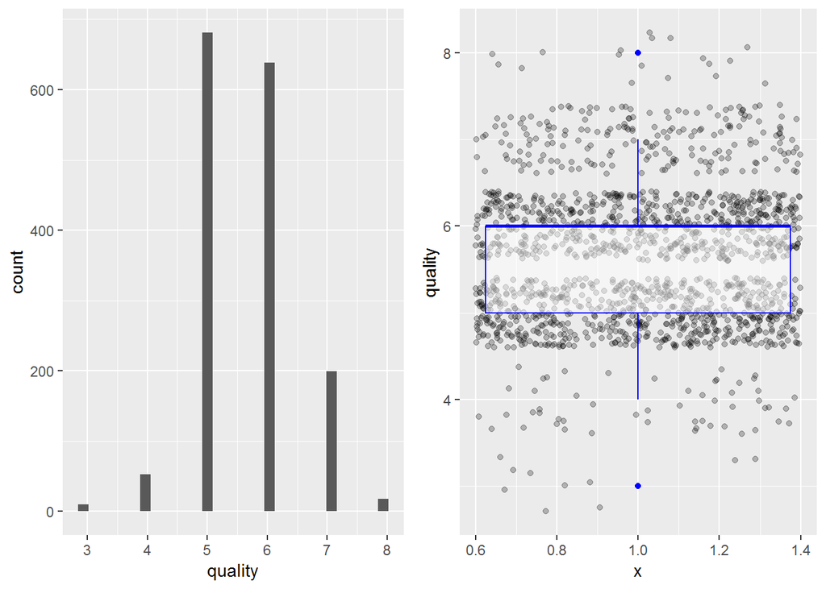

We can easily see the difference between number of observations for the values of quality. Despite that, the distribution is normal and there aren’t a lot of outliers on the feature.

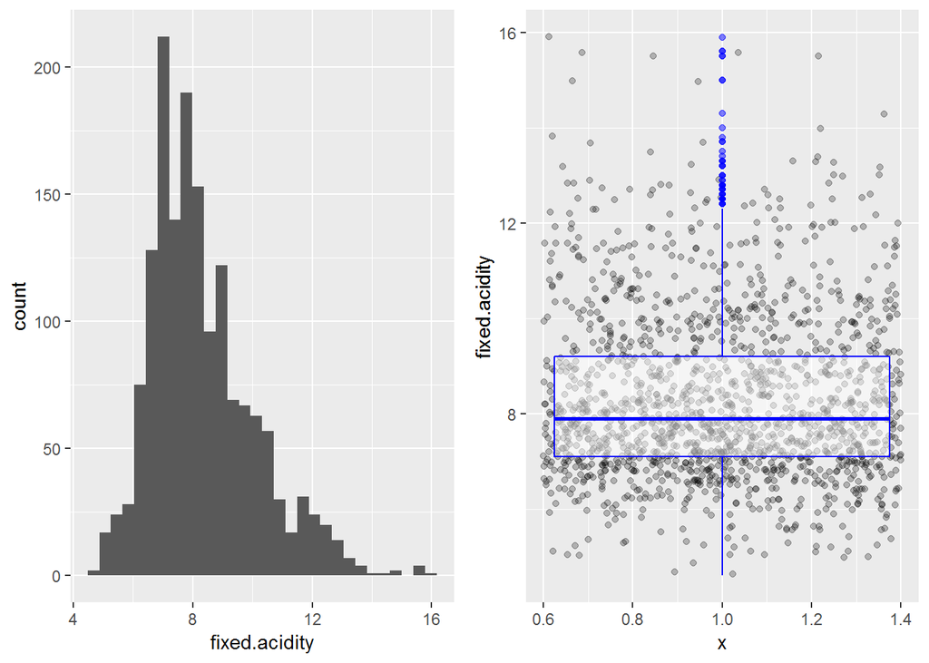

Fixed acidity has a more sparse distribution, although still normal-like. There are a higher number of outliers on the higher end, however. These could either be removed or omitted on future plots.

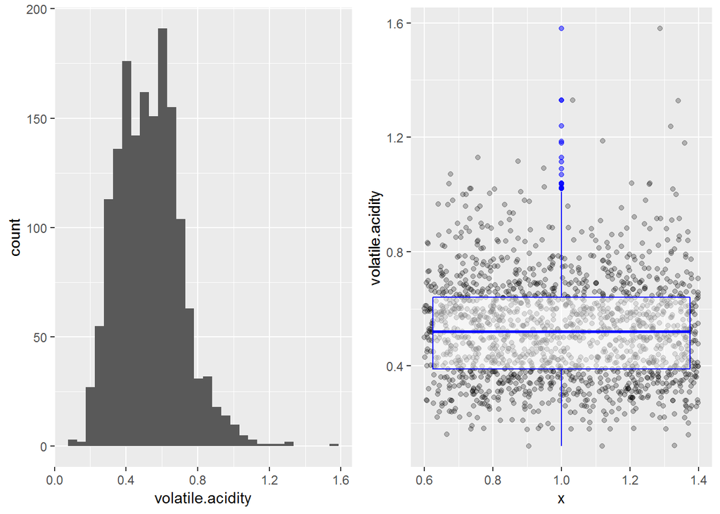

Volatile acidity has a similar distribution as fixed acidity, but with less outliers on the higher end. Again, this could be either removed completely or omitted on future plots.

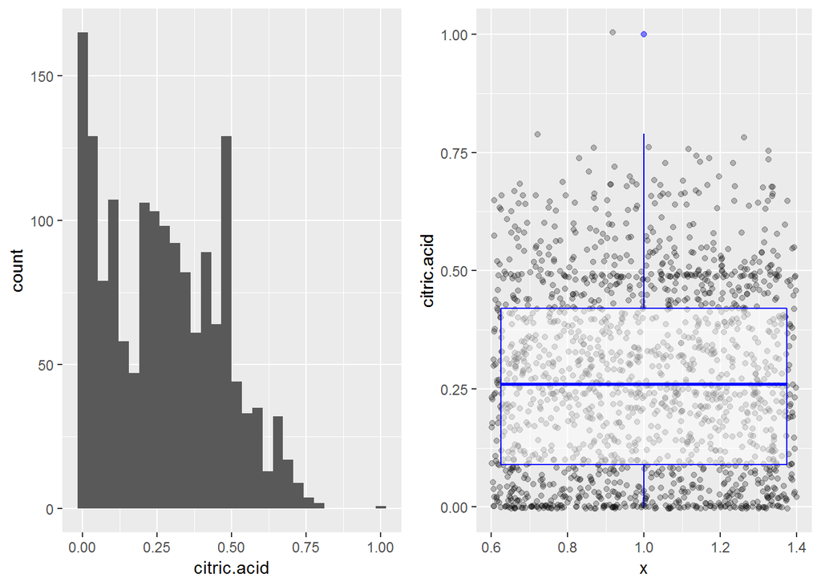

Citric acid has the most disperse distribution so far. The boxplot sections are larger and there are almost no outliers. However, the data does not follow a normal distribution.

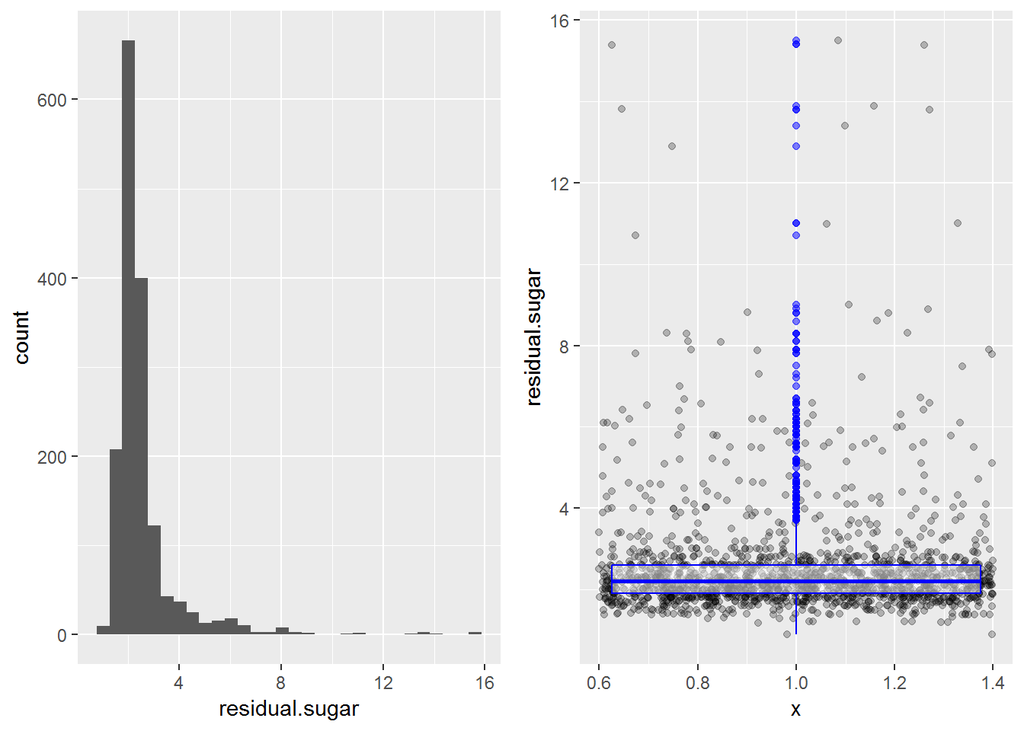

Residual sugar has a very large number of outliers. So much that it is hard to do a proper analysis on these plots. To solve this, we could either transform the feature with a log of square root transformation, and/or remove or omit the outliers.

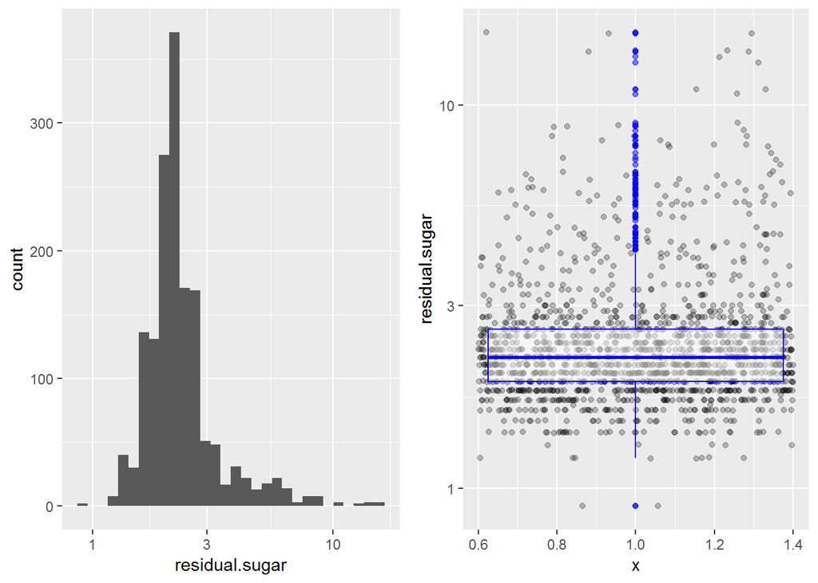

With a log transformation, it is easier to understand the distribution of the feature, but there’s still a lot of outliers difficulting the process.

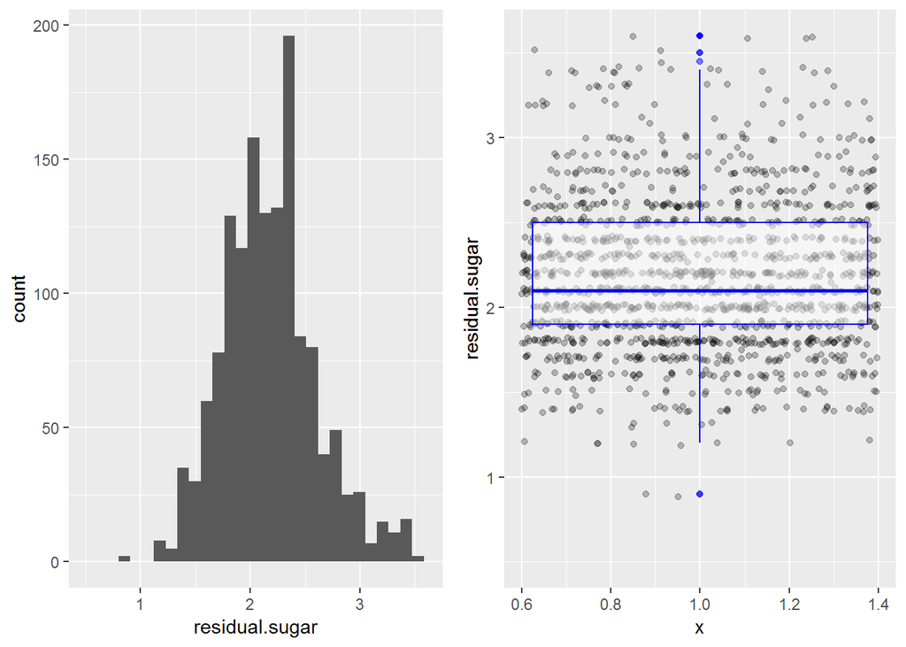

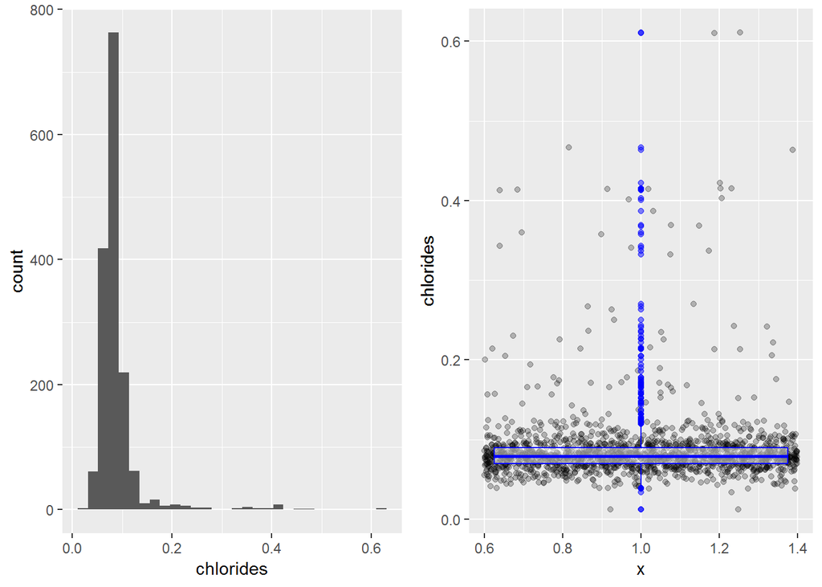

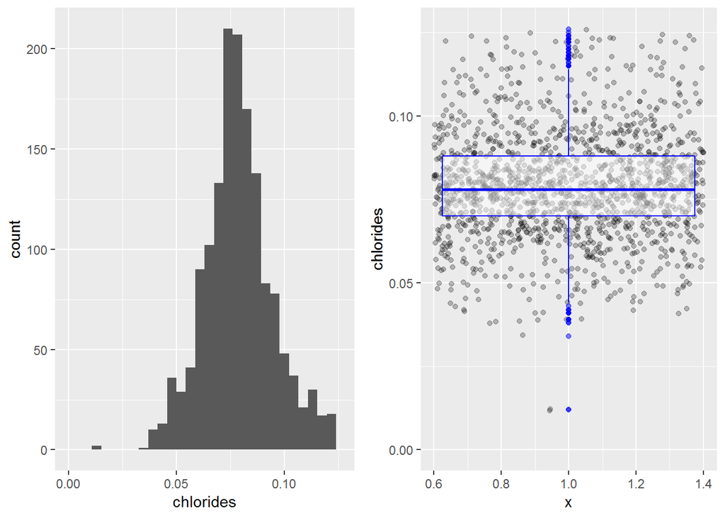

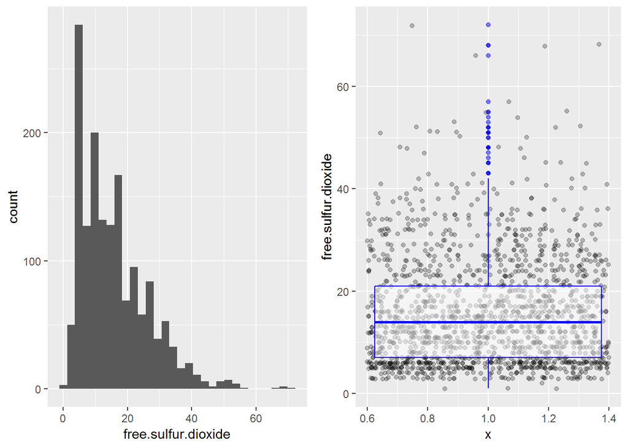

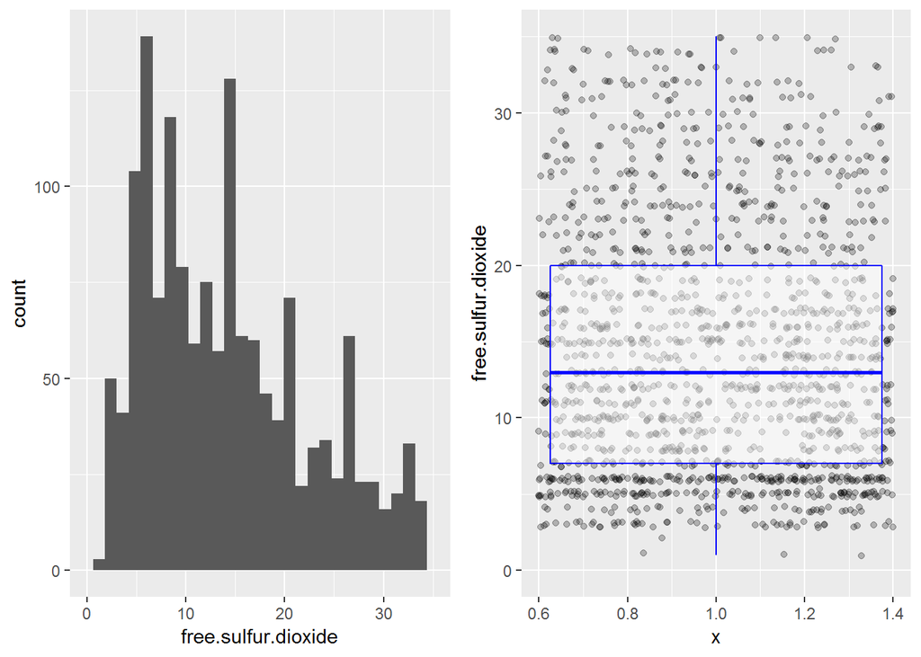

Now we can see that the feature doesn’t follow a normal distribution, since there are a lot of random peaks throughout the histogram.

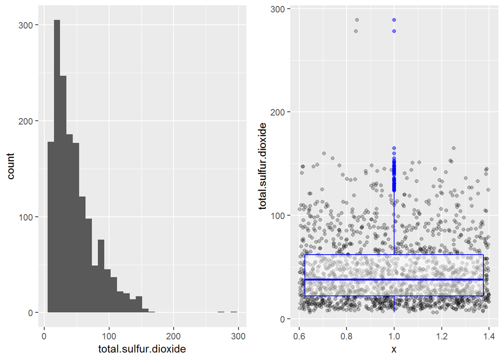

For this feature, there are some observations that have values really apart from the rest of the data. The rest of the data seems reasonable enough to analyze, so I’ll omit those heavy outliers.

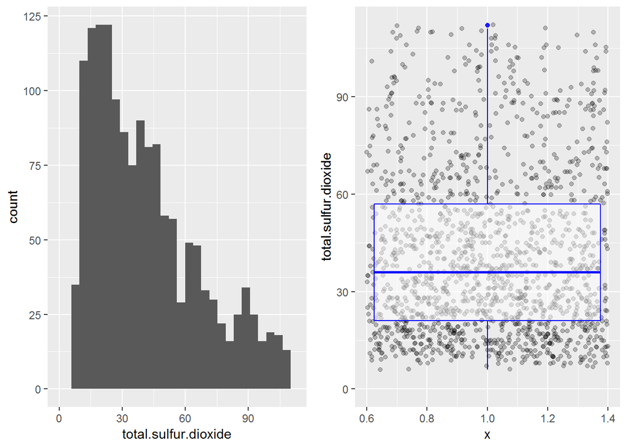

After omitting the top 5%, it is easier to identify other properties of the distribution, such as the mean, where most of the values are concentrated, etc.

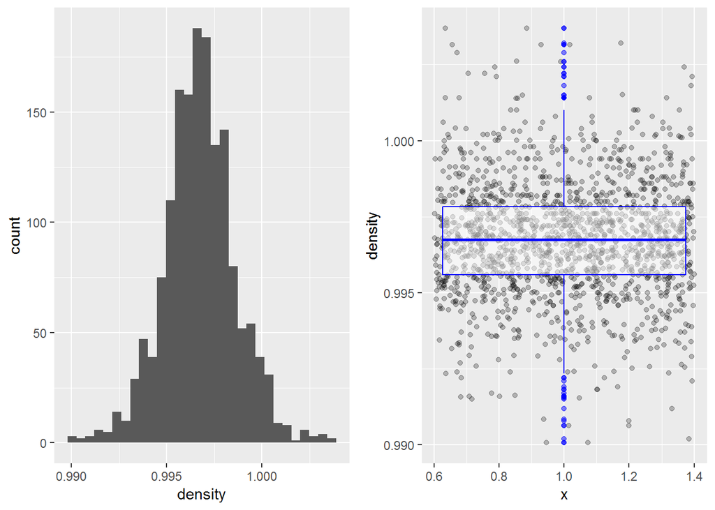

Density is a feature with a normal distribution and outliers on both ends. Most of the values are between 0.995 and 0.9975. Despite the outliers, the plots look easy to analyse.

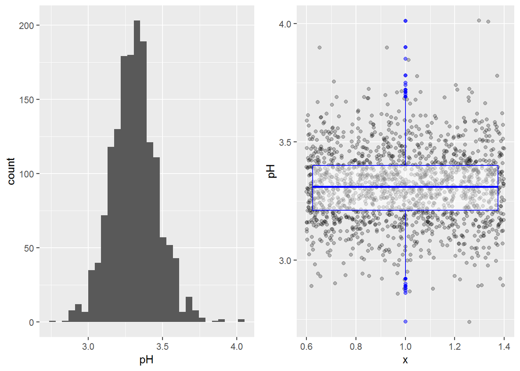

As with density, pH has a few outliers on both ends but that doesn’t difficult visualization that much. The distribution is normal, with most of the values between 3 and 3.5.

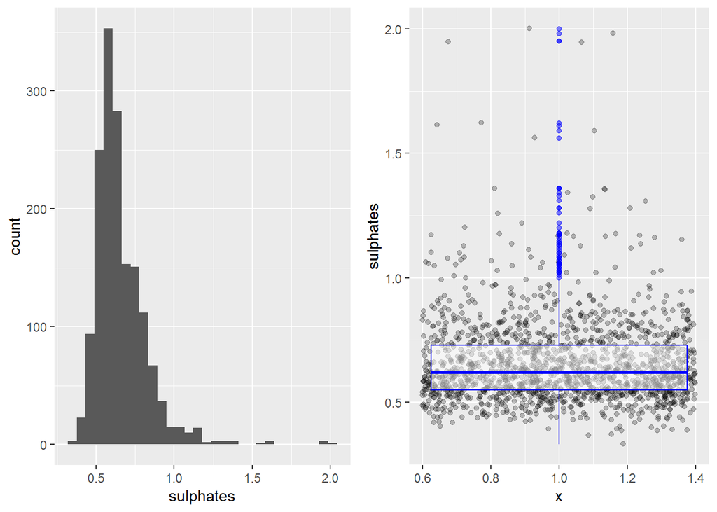

Sulphates as a feature seems to have a normal distribution, but it also holds a lot of outliers on the top end. It might be necessary to omit some of those on later plots.

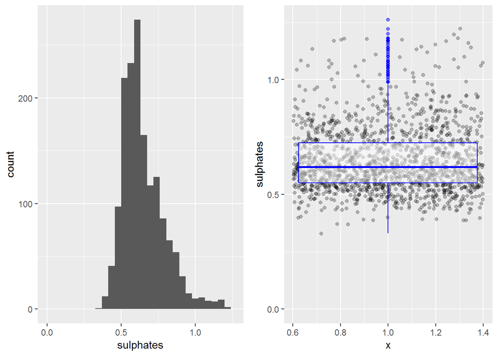

Omitting the top 1% gives a better view of the distribution, even with a few outliers remaining. Most of the observations are within the values of 0.5 and 0.75.

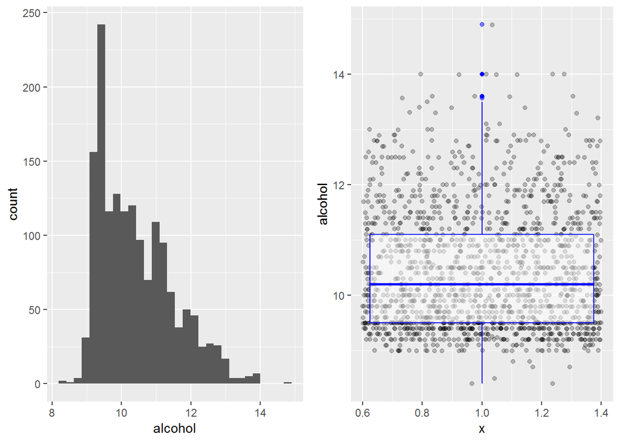

Most of the wines have values of alcohol between 9 and 11. Around 25% of the observations are over 11. The distribution seems relatively normal.

For some of the features it might be useful to divide them into buckets. For quality, reducing the various possible values into buckets helps plot visualization and understanding how the values fare against each other. Features like alcohol and density can naturally describe properties of the wines in a easy to understand way (e.g. lighter, more alcoholic, etc.). The three features will be divided into buckets and be used in both ways (continuous and categorical) onwards.

For quality, the baskets are:

- Bad: 4 or lower quality
- Average: 5 quality
- Good: 6 quality
- Best: 7 or over quality

The choice of breaks for the baskets are based on the fact that most observations on the dataset have quality of 5 or 6.

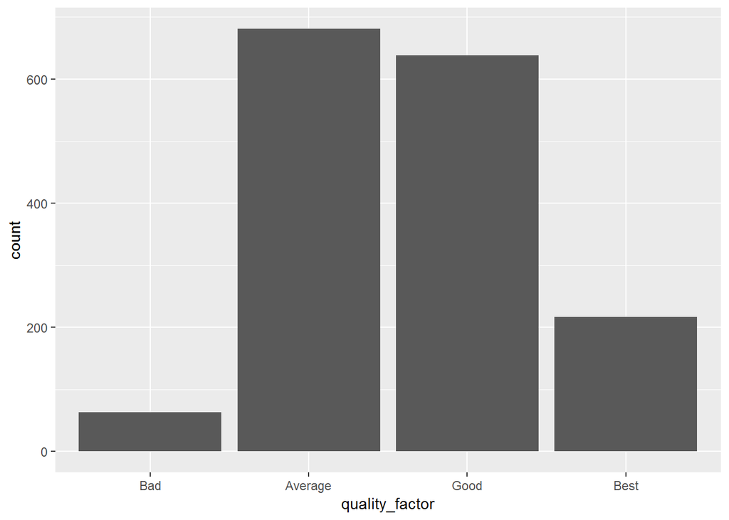

Since most of the wines have quality of 5 or 6, most of them are being described here as “Average” or “Good”, with a good ammount of “Best”.

- Low alcohol level: over 8.4% or under or equal to 9.55%
- Medium alcohol level: over 9.55% or under or equal to 11.7%
- High alcohol level: over 11.7%

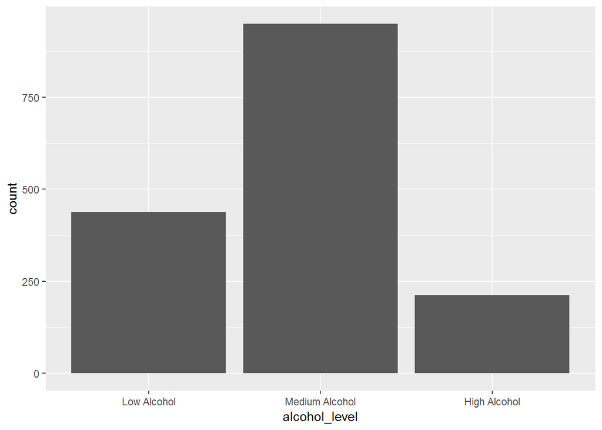

Most wines are bucketed into Medium Alcohol, followed by Low Alcohol and High Alcohol. Although there is a big difference in the number of observations between the buckets, they all have a reasonable number to investigate.

The variance in density levels is 0.0136. By diving in three equal steps, we’ve got roughly 0.0045 for each step. However, the first step doesn’t even surpass the first quartile, and the second goes from there to beyond the third. That would create a bucket with the majority of the observations. Looking to create more even buckets, I’ll use the values from the first quartile, median and third quartile.

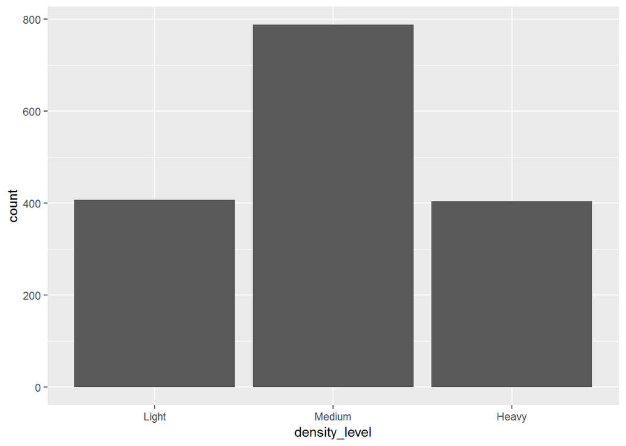

The distribution seems more balanced, even with the middle bucket with almost double the number of observations of the other buckets. The buckets are represented in the following manner:

- Light wines: up to 0.9956g/cm^3
- Medium wines: higher than 0.9956g/cm^3 and up to 0.9978g/cm^3
- Heavy wines: higher than 0.9978g/cm^3

# Univariate Analysis

The dataset consists of 1599 observations of red wines with information about 11 physicochemical properties and 1 information about the quality of each wine. The pyhisicochemial information was collected with experiments and the quality of each wine is a mean of a value provided by different wine experts. All the information is in the form of numbers.

The quality values were given in a scale from 0 (very bad) to 10 (very excellent). However, the majority of the wines have quality of 5 or 6. The worst wine has a quality of 3. The best wine has a quality of 8.

Some features are long-tailed. Examples are residual sugar, chlorides, free sulfur dioxide, total sulfur dioxide, and sulphates.

With a few exceptions, the features have a distribution close to normal.

Since quality is the output feature of the study that generated this dataset, the feature is undoubtly the main feature of interest.

For the variance observed in some of these features and their nature in relation to overall taste in wine, I would describe residual sugar, density and pH as features of interest.

# Bivariate Plots Section

I’ve established some features of interest, but that was mainly done looking at their distribution and common wine knowledge. It would be best to evaluate the correlation between the features, to identify if the choices made are the best ones or if there is some possible feature worth considering.

```
##                      fixed.acidity volatile.acidity citric.acid
## fixed.acidity           1.00000000     -0.256130895  0.67170343
## volatile.acidity       -0.25613089      1.000000000 -0.55249568
## citric.acid             0.67170343     -0.552495685  1.00000000
## residual.sugar          0.11477672      0.001917882  0.14357716
## chlorides               0.09370519      0.061297772  0.20382291
## free.sulfur.dioxide    -0.15379419     -0.010503827 -0.06097813
## total.sulfur.dioxide   -0.11318144      0.076470005  0.03553302
## density                 0.66804729      0.022026232  0.36494718
## pH                     -0.68297819      0.234937294 -0.54190414
## sulphates               0.18300566     -0.260986685  0.31277004
## alcohol                -0.06166827     -0.202288027  0.10990325
## quality                 0.12405165     -0.390557780  0.22637251
##                      residual.sugar    chlorides free.sulfur.dioxide
## fixed.acidity           0.114776724  0.093705186        -0.153794193
## volatile.acidity        0.001917882  0.061297772        -0.010503827
## citric.acid             0.143577162  0.203822914        -0.060978129
## residual.sugar          1.000000000  0.055609535         0.187048995
## chlorides               0.055609535  1.000000000         0.005562147
## free.sulfur.dioxide     0.187048995  0.005562147         1.000000000
## total.sulfur.dioxide    0.203027882  0.047400468         0.667666450
## density                 0.355283371  0.200632327        -0.021945831
## pH                     -0.085652422 -0.265026131         0.070377499
## sulphates               0.005527121  0.371260481         0.051657572
## alcohol                 0.042075437 -0.221140545        -0.069408354
## quality                 0.013731637 -0.128906560        -0.050656057
##                      total.sulfur.dioxide     density          pH
## fixed.acidity                 -0.11318144  0.66804729 -0.68297819
## volatile.acidity               0.07647000  0.02202623  0.23493729
## citric.acid                    0.03553302  0.36494718 -0.54190414
## residual.sugar                 0.20302788  0.35528337 -0.08565242
## chlorides                      0.04740047  0.20063233 -0.26502613
## free.sulfur.dioxide            0.66766645 -0.02194583  0.07037750
## total.sulfur.dioxide           1.00000000  0.07126948 -0.06649456
## density                        0.07126948  1.00000000 -0.34169933
## pH                            -0.06649456 -0.34169933  1.00000000
## sulphates                      0.04294684  0.14850641 -0.19664760
## alcohol                       -0.20565394 -0.49617977  0.20563251
## quality                       -0.18510029 -0.17491923 -0.05773139
##                         sulphates     alcohol     quality
## fixed.acidity         0.183005664 -0.06166827  0.12405165
## volatile.acidity     -0.260986685 -0.20228803 -0.39055778
## citric.acid           0.312770044  0.10990325  0.22637251
## residual.sugar        0.005527121  0.04207544  0.01373164
## chlorides             0.371260481 -0.22114054 -0.12890656
## free.sulfur.dioxide   0.051657572 -0.06940835 -0.05065606
## total.sulfur.dioxide  0.042946836 -0.20565394 -0.18510029
## density               0.148506412 -0.49617977 -0.17491923
## pH                   -0.196647602  0.20563251 -0.05773139
## sulphates             1.000000000  0.09359475  0.25139708
## alcohol               0.093594750  1.00000000  0.47616632
## quality               0.251397079  0.47616632  1.00000000
```

Based on correlations, the best features to predict the quality of a wine are, in order, alcohol, volatile acidity and sulphates. My initial intuition was that residual sugar, density and pH would better describe the quality of a wine, with alcohol and acidity features as possible features to look afterwards. These initial findings show that there is more to the quality of a wine than what common knowledge says.

With the correlation knowledge, I’ll try now to visualize the influence of those features on the quality of the wines.

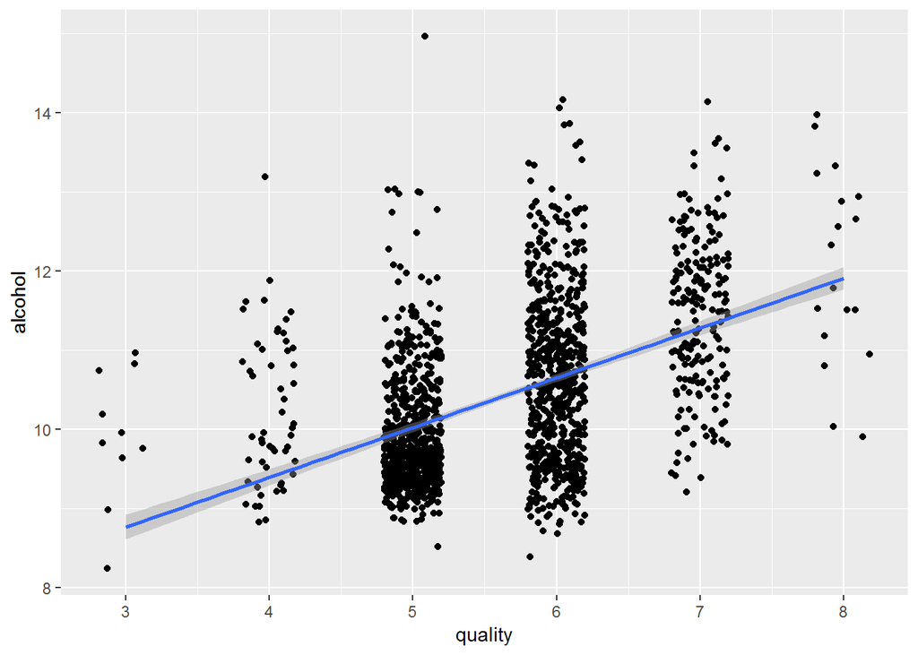

The scatterplot suggests that as the percentage of alcohol increases so does the overall quality of the wine, as shown by the linear regression line. Even when comparing quality of 5 and 6 (the most common on the dataset), the observations tend to go up on quality 6, whilst being clumped below the regression line on quality 5.

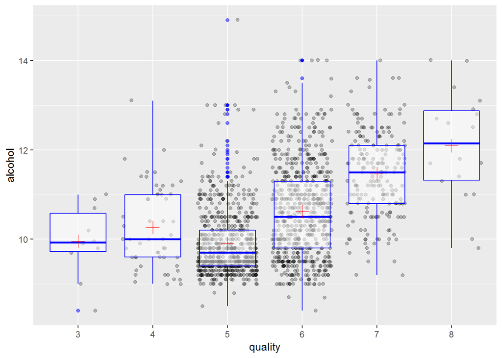

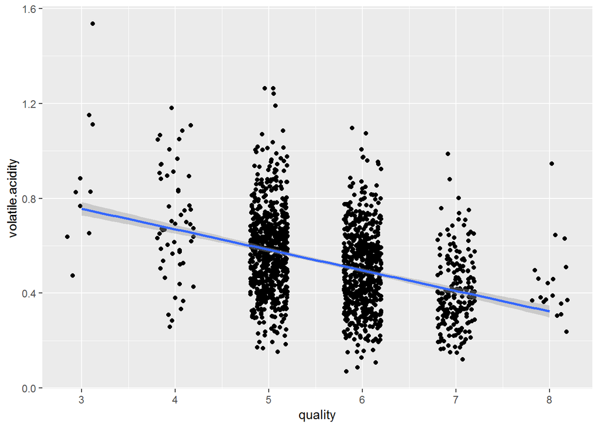

Volatile acidity is the opposite as alcohol: as it increases, the overall quality of the wine decreases. Since the correlation found was negative (around -0.39), that was expected.

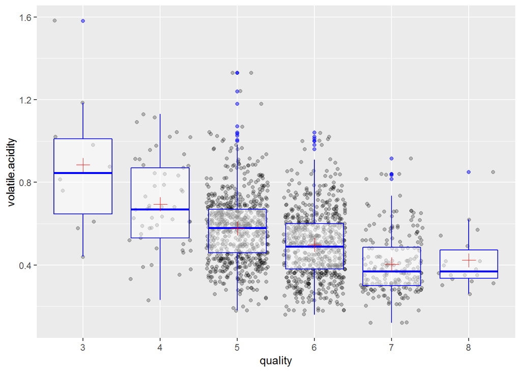

Again, the boxplots suggests the same and provide additional information (mean and median values for each quality). As the level of volatile acidity decreases, the perceived quality of the wine increases.

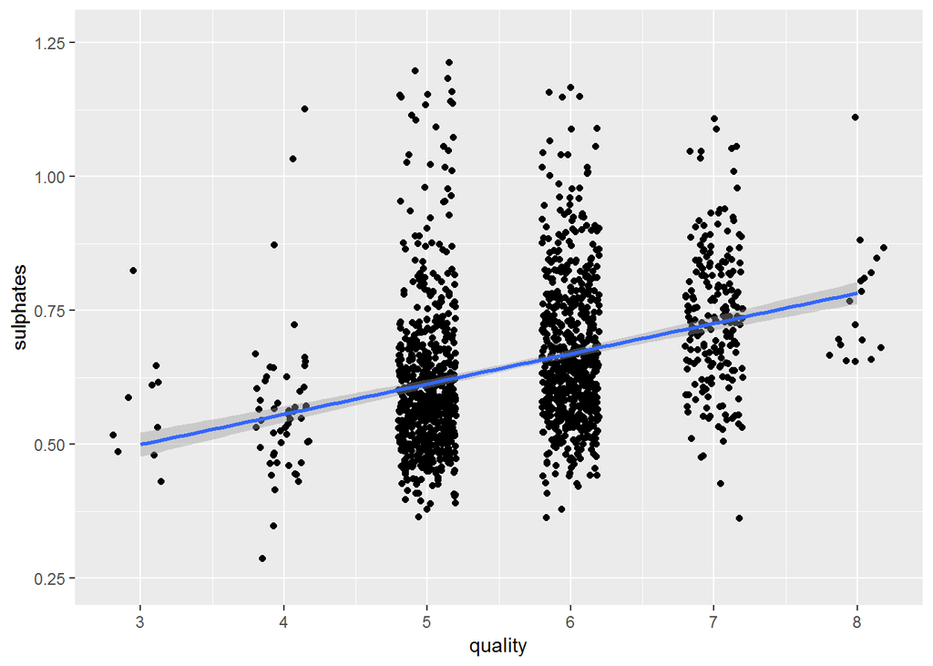

The top 1% for sulphates was removed for better visualization. For sulphates, the scatterplot has a behavior similar to alcohol: better quality wines have higher levels of sulphates.

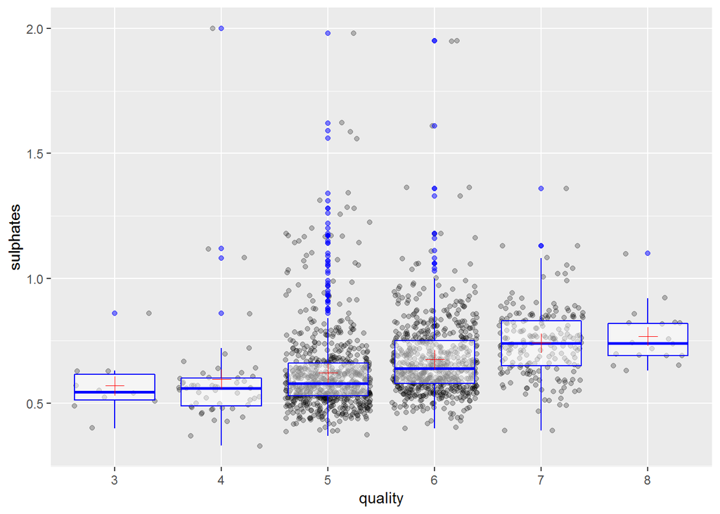

The boxplot for each quality supports that trend. All the higher qualities have a higher mean and median values of sulphates.

By plotting these three features on scatterplots and boxplots against quality, it is easier to visualize their influence on the quality of the wines. By now, it is safe to say that better wines probably have higher alcohol and sulphates levels, whilst having a lower volatile acidity level.

Since citric acid is the fourth most correlated feature to quality, it is worth doing some analysis on it.

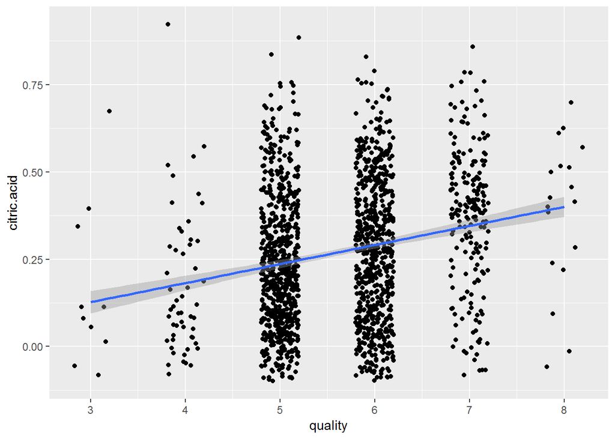

The correlation between citric acid and quality (~0.226) is not much different from the correlation between sulphates and quality (~0.25), so their tendencies are also similar to each other. Better wines tend to have, on average, higher levels of citric acid.

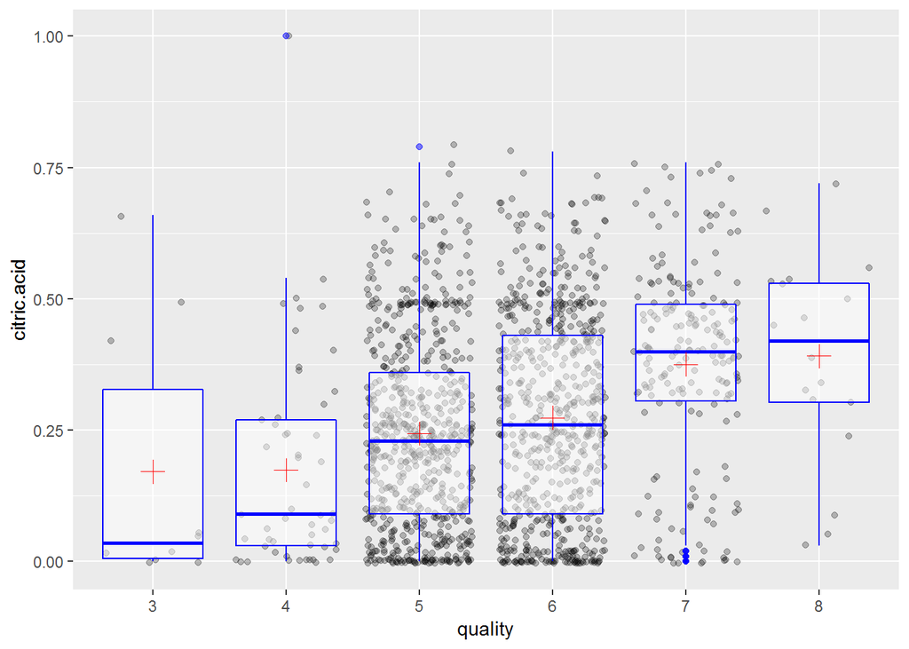

For the boxplot between citric acid and quality, we can see a clear difference between better wines (quality of 7 and 8) and the other ones. Not only they tend to have higher values of citric acid, the majority of their observations (over 75%) are over 0.25g/dm^3 of citric acid.

Since density is a feature most commonly used when describing “the body” of the wine, I’ll do a similar analysis for it.

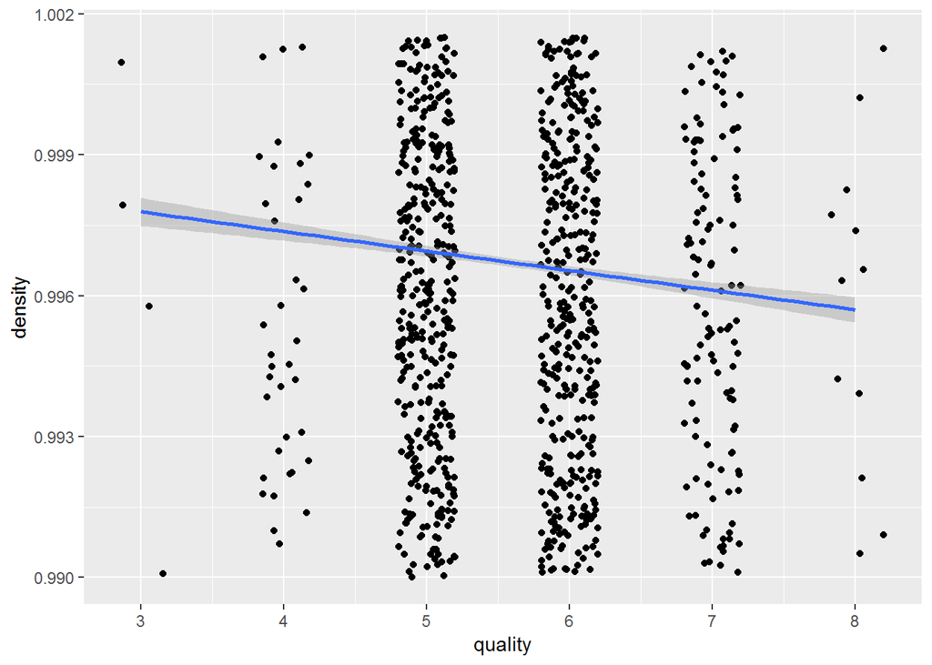

The top 1% for density was removed for better visualization. Since the correlation between these features is very low (around -0.17), the influence of density on the quality of the wine is lower than previous features. It seems that using density to evaluate the quality of a wine (a common practice of non-experts) is not the best approach.

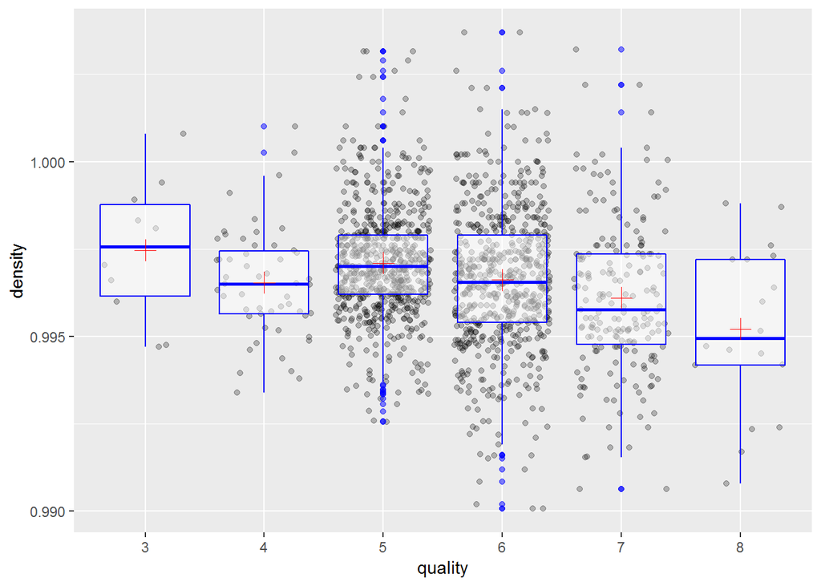

The boxplot adds a little more information. There is a decrease of density levels on better wines, but that is only noticeable with quality levels of 7 and 8. For the other quality levels, there doesn’t seem to be a significant difference.

# Bivariate Analysis

I’ve investigated the relationships between quality and alcohol, volatile acidity, sulphates, citric acid and density. In terms of correlation with quality, they were, in order, 1st, 2nd, 3rd, 4th and 6th most correlated features of the dataset. The first four were chosen because of they closer relationship with quality and density was chosen out of personal curiosity.

Alcohol was the feature most correlated with quality, with a factor of 0.48. The positive correlation between them implied that increasing the level of alcohol would increase the perceived quality of the wine. The plots created demonstrated that assumption.

Volatile acidity was the second feature most correlated with quality, with a factor of -0.39. The negative correlation implies a decrease of one when an increase in the other occurs. The plots generated help visualize that relationship. As volatile acidity levels go down, the quality of the wines go up.

Sulphates and citric acid where the third and fourth most correlated qualities, with factors of 0.25 and 0.226, respectively. Higher levels of these features are correlated with better quality of the wine, although their influence is not as strong as the influence of alcohol and volatile acidity.

Density was the sixth most correlated feature with quality. The choice to visualize the influence of that feature was mostly curiosity based, since the correlation factor is of only -0.175. Although there is an influence of the feature on the quality of the wine, that influence is only noteworthy on the best wines on the dataset (7 or above). Those wines tend to have a lower density value.

Features related to acidity naturally seem to be correlated with each other. Examples are fixed acidity, volatile acidity, citric acid and pH. Density also seems to be related with those features, along with residual sugar and alcohol.